# Assignment 4

Jennifer Horowitz

9/30/2020

```r
library(tidyverse)
library(jtools)
library(interactions)
library(ggthemes)
```

```r
baseball <- read.csv('baseballtidy.csv')

baseball <- baseball %>%
select(-X)
```

### Linear Regression

#### Model 1

The model shows that there is a positive relationship between weight and batting average. For every pound increase in weight, the batting average increase 0.0003. Weight has a p value of 0.21 which is not statistically significant.

Height is statistically significant. Every inch in height decreases batting average by .008130894.

Bats left is not statistically significant. If you bat left your batting average would go down .01 points.

Bats right is statistically significant. If you bat right your batting average would down 0.04 points.

Slugging average is statistically significant. If your slugging average is positive then your batting average goes up .9.

GDP per capita is not statistically significant. If your GDP per capita goes up then batting average goes down by a very small margin.

North American-born players are not statistically significant. If you’re from North America your batting average goes up .05.

Players born in Europe and Asia were not statistically significant. If you are from Europe/Asia then your batting average goes up .06.

Players from South America were not statistically significant. If you are from South America then your batting average goes up .12.

My adjusted R-squared . 3482. It only explains 35% of the variance.

```r
model1 <- lm(batting_average~.,data=baseball)
summary(model1)
```

```
##
## Call:
## lm(formula = batting_average ~ ., data = baseball)
##
## Residuals:
##      Min       1Q   Median       3Q      Max
## -0.24820 -0.05688  0.02588  0.07359  0.22008
##
## Coefficients:
##                            Estimate   Std. Error t value             Pr(>|t|)
## (Intercept)             0.761255317  0.131530671   5.788         0.0000000105
## weight                  0.000330682  0.000263677   1.254             0.210192
## height                 -0.008130894  0.002163078  -3.759             0.000184
## batsL                  -0.014066844  0.013111873  -1.073             0.283694
## batsR                  -0.044006710  0.012121217  -3.631             0.000302
## slugging_average        0.905802012  0.046819261  19.347 < 0.0000000000000002
## gdp_per_capita         -0.000001739  0.000002358  -0.737             0.461060
## continentNorth America  0.054502079  0.065762086   0.829             0.407496
## continentother          0.060874048  0.064636181   0.942             0.346603
## continentSouth America  0.122473914  0.102079364   1.200             0.230602
##
## (Intercept)            ***
## weight
## height                 ***
## batsL
## batsR                  ***
## slugging_average       ***
## gdp_per_capita
## continentNorth America
## continentother
## continentSouth America
## ---
## Signif. codes:  0 '***' 0.001 '**' 0.01 '*' 0.05 '.' 0.1 ' ' 1
##
## Residual standard error: 0.1 on 745 degrees of freedom
##   (2 observations deleted due to missingness)
## Multiple R-squared:  0.356,  Adjusted R-squared:  0.3482
## F-statistic: 45.75 on 9 and 745 DF,  p-value: < 0.00000000000000022
```

### Model 2

#### Interaction Term with GDP Per Term Continent

GDP per capita is often tied to what continent it relates to so the interaction term I will use is GDP per capita and continent

My adjusted R squared was .3466. Which was slightly worse than model 1.

```r
model2 <- lm(batting_average~.+ gdp_per_capita:continent,data=baseball)
summary(model2)
```

```
##
## Call:
## lm(formula = batting_average ~ . + gdp_per_capita:continent,
##     data = baseball)
##
## Residuals:
##      Min       1Q   Median       3Q      Max
## -0.24844 -0.05763  0.02575  0.07331  0.22008
##
## Coefficients: (1 not defined because of singularities)
##                                           Estimate   Std. Error t value
## (Intercept)                            0.745258937  0.148163909   5.030
## weight                                 0.000331735  0.000264011   1.257
## height                                -0.008161715  0.002166874  -3.767
## batsL                                 -0.013587044  0.013174321  -1.031
## batsR                                 -0.043733833  0.012157154  -3.597
## slugging_average                       0.907054270  0.047099243  19.258
## gdp_per_capita                         0.000003231  0.000019970   0.162
## continentNorth America                 0.086778696  0.108744281   0.798
## continentother                         0.035166952  0.162654016   0.216
## continentSouth America                 0.127211147  0.103917575   1.224
## gdp_per_capita:continentNorth America -0.000005456  0.000020150  -0.271
## gdp_per_capita:continentother         -0.000003321  0.000020675  -0.161
## gdp_per_capita:continentSouth America           NA           NA      NA
##                                                   Pr(>|t|)
## (Intercept)                                    0.000000616 ***
## weight                                            0.209323
## height                                            0.000179 ***
## batsL                                             0.302723
## batsR                                             0.000343 ***
## slugging_average                      < 0.0000000000000002 ***
## gdp_per_capita                                    0.871517
## continentNorth America                            0.425121
## continentother                                    0.828886
## continentSouth America                            0.221282
## gdp_per_capita:continentNorth America             0.786622
## gdp_per_capita:continentother                     0.872438
## gdp_per_capita:continentSouth America                   NA
## ---
## Signif. codes:  0 '***' 0.001 '**' 0.01 '*' 0.05 '.' 0.1 ' ' 1
##
## Residual standard error: 0.1001 on 743 degrees of freedom
##   (2 observations deleted due to missingness)
## Multiple R-squared:  0.3561, Adjusted R-squared:  0.3466
## F-statistic: 37.36 on 11 and 743 DF,  p-value: < 0.00000000000000022
```

### Model 3

#### Using only the 3 significant variables.

Only the models that were significant in model 1.

My adjusted R squared is .3493 which is my best model so far.

```r
model3 <- lm(batting_average~ height + bats + slugging_average,data=baseball)
summary(model3)
```

```
##
## Call:
## lm(formula = batting_average ~ height + bats + slugging_average,
##     data = baseball)
##
## Residuals:
##      Min       1Q   Median       3Q      Max
## -0.23753 -0.05666  0.02584  0.07434  0.20976
##
## Coefficients:
##                   Estimate Std. Error t value             Pr(>|t|)
## (Intercept)       0.693080   0.121007   5.728         0.0000000147 ***
## height           -0.006298   0.001675  -3.761             0.000182 ***
## batsL            -0.014652   0.012976  -1.129             0.259207
## batsR            -0.044132   0.011897  -3.709             0.000223 ***
## slugging_average  0.909402   0.046277  19.651 < 0.0000000000000002 ***
## ---
## Signif. codes:  0 '***' 0.001 '**' 0.01 '*' 0.05 '.' 0.1 ' ' 1
##
## Residual standard error: 0.09982 on 752 degrees of freedom
## Multiple R-squared:  0.3527, Adjusted R-squared:  0.3493
## F-statistic: 102.4 on 4 and 752 DF,  p-value: < 0.00000000000000022
```

### Visualizing the results

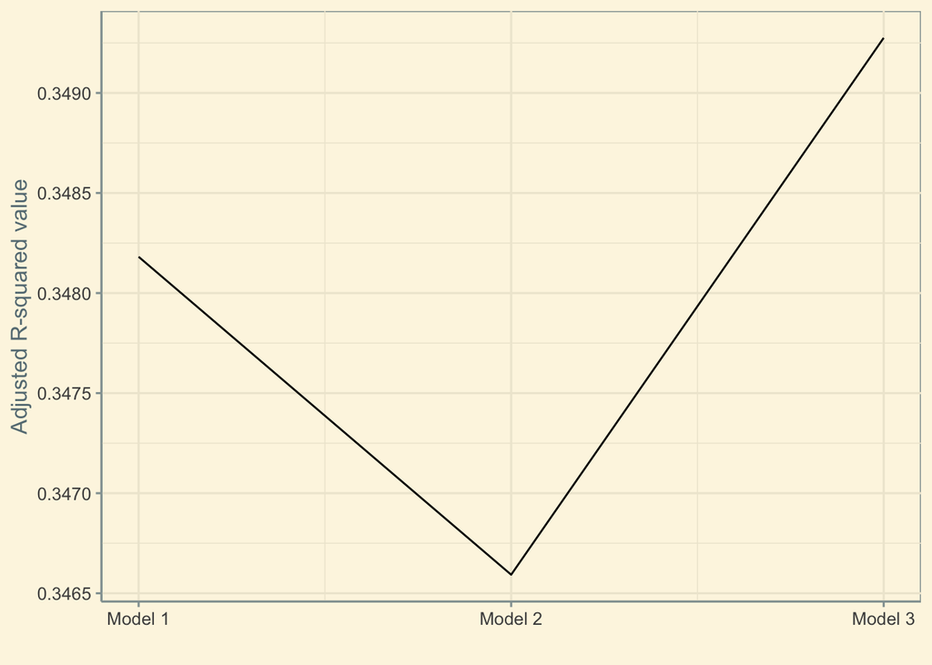

```r
ModelFit <- tibble(model = c(1, 2, 3),
                   R_square = c(summary(model1)$adj.r.squared,
                                summary(model2)$adj.r.squared,
                                summary(model3)$adj.r.squared))
ggplot(ModelFit, aes(x = model, y = R_square)) +
  geom_line() +
  scale_x_continuous(name = "",
                   breaks = breaks <- seq(1, 3, by = 1),
                   labels = paste("Model", breaks)) +
  scale_y_continuous(name = "Adjusted R-squared value") +
  theme_solarized()
```

Model 3 is the best of the models based on the R-squared.